# Amazon Polly: Can it handle accented English?

We first collected all the scores for each sentence and then found the mean Levenshtein score for that sentence, storing the results in a new DataFrame alongside the original version of the sentence which Polly received. We then created a scatter plot displaying the mean Levenshtein score for each sentence.

```python
import numpy as np
```

```python
sentence_avg = pd.DataFrame()
sentence_avg['Original'] = clean_df['Original']
sentence_avg['Sentence Number'] = clean_df['Sentence Number']
sentence_avg['Average Score'] = pd.Series()

for i in range(1, 101):
  subset = clean_df[clean_df['Sentence Number'] == i]
  sentence_avg['Average Score'][i-1] = np.mean(subset['Score'])
```

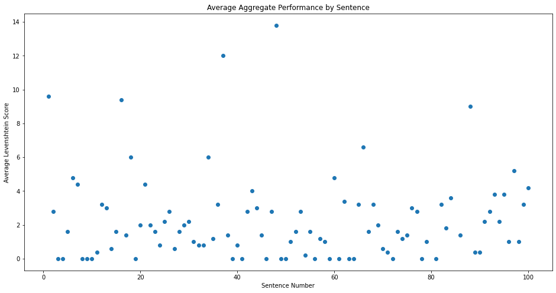

```python
plt.figure(figsize=(16, 8))
plt.plot('Sentence Number', 'Average Score', 'o', data = sentence_avg)
plt.title('Average Aggregate Performance by Sentence')
plt.xlabel('Sentence Number')
plt.ylabel('Average Levenshtein Score')
```

Not all sentences are created equal! Transcription interpreted some of them perfectly, but made several errors on others. Our next step was to subset the data once more and look at only those sentences that hadd an average Levenstein score greater than five – in other words, we wanted to focus on the sentences which gave Transcribe the most difficulty.

```python
worst = sentence_avg[sentence_avg['Average Score'] > 5]
worst_sentences = worst['Original']
all_worst = clean_df[clean_df['Original'].isin(worst_sentences)]
```

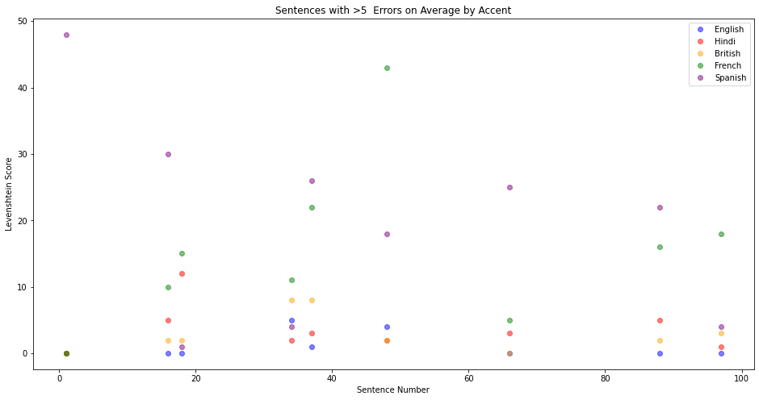

```python
eng = all_worst[all_worst['Language'] == 'English']
hin = all_worst[all_worst['Language'] == 'Hindi']
brit = all_worst[all_worst['Language'] == 'British']
french = all_worst[all_worst['Language'] == 'French']
span = all_worst[all_worst['Language'] == 'Castilian Spanish']

plt.figure(figsize=(16, 8))
plt.plot('Sentence Number', 'Score', 'o', data = eng, color = 'blue', alpha = 0.5)
plt.plot('Sentence Number', 'Score', 'o', data = hin, color = 'red', alpha = 0.5)
plt.plot('Sentence Number', 'Score', 'o', data = brit, color = 'orange', alpha = 0.5)
plt.plot('Sentence Number', 'Score', 'o', data = french, color = 'green', alpha = 0.5)
plt.plot('Sentence Number', 'Score', 'o', data = span, color = 'purple', alpha = 0.5)
plt.legend(labels = ['English', 'Hindi', 'British', 'French', 'Spanish'])
plt.title('Sentences with >5  Errors on Average by Accent')
plt.xlabel('Sentence Number')
plt.ylabel('Levenshtein Score')
```

Unsurprisingly, the results from French and Castilian Spanish skewed the results of most of these sentences toward the more erroneous side. For the vast majority of sentences, English, British and Hindi are grouped fairly close to one another – and sometimes all five are relatively consistent – but French and Castilian Spanish are far above. Let's take a look at the worst sentences for French and Castilian Spanish to see if examining the specific data points can illuminate the issue.

```python
span
```

|  | Index | Sentence Number | Name | Language | Original | Transcription | Score |
| --- | --- | --- | --- | --- | --- | --- | --- |
| 400 | 500 | 1 | Lucia | Castilian Spanish | Gwen had her best sleep ever on her new bed of... | Nails | 48 |
| 415 | 515 | 16 | Lucia | Castilian Spanish | It dawned on her that others could make her ha... | Could make her happier but only she could make... | 30 |
| 417 | 517 | 18 | Lucia | Castilian Spanish | The thunderous roar of the jet overhead confir... | The thunderous roar of the yet overhead confir... | 1 |
| 433 | 533 | 34 | Lucia | Castilian Spanish | Everyone pretends to like wheat until you ment... | Everyone pretends to like quit until you menti... | 4 |
| 436 | 536 | 37 | Lucia | Castilian Spanish | Nudist colonies shun fig-leaf couture | Nudist Colony | 26 |
| 447 | 547 | 48 | Lucia | Castilian Spanish | A purple pig and a green donkey flew a kite in... | Purple pink and the green donkey flew a kite i... | 18 |
| 465 | 565 | 66 | Lucia | Castilian Spanish | Pink horses galloped across the sea | Pink Horses | 25 |
| 487 | 587 | 88 | Lucia | Castilian Spanish | It was always dangerous to drive with him sinc... | It was always the injuries to drive with him s... | 22 |
| 496 | 596 | 97 | Lucia | Castilian Spanish | Her scream silenced the rowdy teenagers | First scream silenced the rowdy teenagers | 4 |

```python
french
```

|  | Index | Sentence Number | Name | Language | Original | Transcription | Score |
| --- | --- | --- | --- | --- | --- | --- | --- |
| 200 | 200 | 1 | Lea | French | Gwen had her best sleep ever on her new bed of... | Gwen had her best sleep ever on her new bed of... | 0 |
| 215 | 215 | 16 | Lea | French | It dawned on her that others could make her ha... | It doesn't have that others could make her hap... | 10 |
| 217 | 217 | 18 | Lea | French | The thunderous roar of the jet overhead confir... | The restaurant of the jet overhead confirmed t... | 15 |
| 233 | 233 | 34 | Lea | French | Everyone pretends to like wheat until you ment... | Everyone pretends to like quit until you menti... | 11 |
| 236 | 236 | 37 | Lea | French | Nudist colonies shun fig-leaf couture | Nudist colonies | 22 |
| 247 | 247 | 48 | Lea | French | A purple pig and a green donkey flew a kite in... | The purple pig and the green in the middle of ... | 43 |
| 265 | 265 | 66 | Lea | French | Pink horses galloped across the sea | Being courses galloped across the sea | 5 |
| 287 | 287 | 88 | Lea | French | It was always dangerous to drive with him sinc... | It was always dangerous to drive with him sinc... | 16 |
| 296 | 296 | 97 | Lea | French | Her scream silenced the rowdy teenagers | The screams I learned to the rail woody teenag... | 18 |

The outlier data points appear to come from sentences in which the accent was so unintelligible to Transcribe that it only transcribed a handful of words from the sentence, resulting in an embarrassingly high Levenshtein score. For the mast majority, however, the mistakes were what we would expect: the words were slightly altered in a way that makes it clear that Transcribe had difficulty discerning exactly where one word ended and another began (i.e. French sentence number 66: "Pink horses" vs. "Being courses"). The phonological differences among the accents confused Transcribe, making it impossible for Transcribe to identify sounds which would otherwise be predictable in American English accents. For some reason, these distinctions are far blurrier for French and Castilian Spanish.

# Conclusions

Amazon's services even made mistakes with a standard American English accent, and all the problems which appeared for that voice were exacerbated for the foreign accents. The results of our hypothesis testing were somewhat surprising: we expected that the Hindi accent would produce a statistically significant difference and the British accent would not, but in reality the opposite occurred. The results for Castilian Spanish and French were more aligned with what we anticipated, although the handful of sentences which incurred 40-50 errors are a point of concern as it pertains to data validity.

While our experiment was an interesting preliminary study, there are many areas on which future ones could improve. For one, the sentence data should not include any punctuation, numbers or symbols which could be arbitrarily mistranscribed. Additionally, a wider range of voices should be included to better represent the diversity of English accents present in the United States and other English-speaking countries today. Because we had to drop the Korean accent due to mass data creation errors, we were unable to include East Asian representation. Lastly, the data set should be expanded to include a larger body of sentences, which will reduce random error and increase our confidence in the results.